# **Modul 5: Market Basket Analysis**

Muhammad Apriandito - Digital Business Experience

### **Reading / Watching Material**

Please read or watch the following material before class starts.

1. [A Gentle Introduction on Market Basket Analysis](https://towardsdatascience.com/a-gentle-introduction-on-market-basket-analysis-association-rules-fa4b986a40ce)
2. [Data Mining: Market Basket Analysis](https://www.youtube.com/watch?v=sVFmbBOXo7A)
3. [Apriori Algorithm Explained | Association Rule Mining | Edureka:](https://www.youtube.com/watch?v=guVvtZ7ZClw)

### **Pretest**

Based on the reading/watching material above, please answer the following questions and collect the answers via Google Classroom.

1. What is Market Basket Analysis?
2. What is Association Rule?
3. State at least 2 association algorithms
4. What is meant by support, confidence, and lift?

### **Case: Dito Mart**

**“Dito Mart”** (A fictional store) used to be a very busy grocery store in Bandung. However, due to the COVID-19 pandemic and there is activity restriction makes Dito Mart is empty of buyers and has experienced a decline in sales. This condition can get worse because there is still a lot of inventory backlog in the warehouse and must be sold immediately.

As a solution, this month Dito Mart wants to try to make a Big Sale by selling their products in bundles. This is an excellent strategy, as well as to reduce the inventory backlog. This big sale is expected to increase Dito Mart’s sales. However, Dito Mart’s management has a fear. They are afraid that if the bundled item is not appropriate, it will cause the package not to be sold.

Fortunately, over the past month, Dito Mart has always recorded customer purchase data in their database. This data is expected to provide information on what products they should sell together in bundles. The data can be accessed via the `Arules` package with name `Groceries`.

#### **Setup**

To be able to access and perform data analysis, the required pacakge must be installed and loaded first.

```r
# Install packages
install.packages(c("arules", "arulesViz"))
```

```r
# Load packages
library("tidyverse")
library("arules")
library("arulesViz")
```

After the required packages are installed and loaded, we can directly import the data. As mentioned abover, the data is contained in `Arules` package with the name `Groceries`. The data can be imported using the `data()` command.

```r
# Load data
data(Groceries)
```

```r
# See data information
print(Groceries)
```

```
## transactions in sparse format with
##  9835 transactions (rows) and
##  169 items (columns)
```

```r
# Example of Item in Transaction
inspect(head(Groceries, 5))
```

```
##     items
## [1] {citrus fruit,
##      semi-finished bread,
##      margarine,
##      ready soups}
## [2] {tropical fruit,
##      yogurt,
##      coffee}
## [3] {whole milk}
## [4] {pip fruit,
##      yogurt,
##      cream cheese ,
##      meat spreads}
## [5] {other vegetables,
##      whole milk,
##      condensed milk,
##      long life bakery product}
```

Each index represents 1 transaction, so items in the same index are items purchased in the same transaction by the same customer.

#### **Market Basket Analysis**

Market Basket Analysis is one of the essential techniques used by large retailers to uncover associations between items by looking for combinations of items that occur together frequently in transactions. Market Basket Analysis uses the Association Rule Mining principle, which is a type of unsupervised learning. Association Rule reviews each transaction containing a number of items (products) and extracts useful relationship patterns among the items in the form of rules. Association Rule are viewed as a two-step approach:

1. Frequent Itemset Generation: Find all frequent item-sets with support
2. Rule Generation: List all Association Rules from frequent item-sets. Calculate Support and Confidence for all rules.

##### **Frequent Itemset Generation**

The first stage in Market Basket Analysis is to find out the frequent itemsets. Frequent items are an item that is often purchased by customers. The association algorithm that will be used is the apriori algorithm. We can set some threshold parameters in the apriori algorithm, such as the minimum or maximum support value (the percentage of these items appears in all transactions). As a note, there is no fixed value for the threshold. The thing to consider is the high support value causes the number of items generated to be too few, and the low support value causes the number of items generated to be too many. In this case, the minimum support value that will be used is 0.001.

```r
# Generate Frequent Itemset
itemsets <- apriori(Groceries,
  parameter = list(
    maxlen = 1,
    support = 0.001,
    target = "frequent itemsets"
  )
)
```

```
## Apriori
##
## Parameter specification:
##  confidence minval smax arem  aval originalSupport maxtime support minlen
##          NA    0.1    1 none FALSE            TRUE       5   0.001      1
##  maxlen            target  ext
##       1 frequent itemsets TRUE
##
## Algorithmic control:
##  filter tree heap memopt load sort verbose
##     0.1 TRUE TRUE  FALSE TRUE    2    TRUE
##
## Absolute minimum support count: 9
##
## set item appearances ...[0 item(s)] done [0.00s].
## set transactions ...[169 item(s), 9835 transaction(s)] done [0.01s].
## sorting and recoding items ... [157 item(s)] done [0.00s].
## creating transaction tree ... done [0.00s].
## checking subsets of size 1
```

```
##  done [0.00s].
## sorting transactions ... done [0.00s].
## writing ... [157 set(s)] done [0.00s].
## creating S4 object  ... done [0.00s].
```

There are 157 items that have support value above 0.001. TThe following is an example of 5 items that have the highest support value.

```r
# 5 Items with the highest support value
inspect(head(sort(itemsets, by = "support"), 5))
```

```
##     items              support   transIdenticalToItemsets count
## [1] {whole milk}       0.2555160 0.012302999              2513
## [2] {other vegetables} 0.1934926 0.006304016              1903
## [3] {rolls/buns}       0.1839349 0.011082867              1809
## [4] {soda}             0.1743772 0.015861718              1715
## [5] {yogurt}           0.1395018 0.004067107              1372
```

##### **Rules Generation**

The next stage is to find out the connection between items or also known as rule generation.

```r
# Show
rules <- apriori(Groceries,
  parameter = list(
    support = 0.001,
    target = "rules"
  )
)
```

```
## Apriori
##
## Parameter specification:
##  confidence minval smax arem  aval originalSupport maxtime support minlen
##         0.8    0.1    1 none FALSE            TRUE       5   0.001      1
##  maxlen target  ext
##      10  rules TRUE
##
## Algorithmic control:
##  filter tree heap memopt load sort verbose
##     0.1 TRUE TRUE  FALSE TRUE    2    TRUE
##
## Absolute minimum support count: 9
##
## set item appearances ...[0 item(s)] done [0.00s].
## set transactions ...[169 item(s), 9835 transaction(s)] done [0.01s].
## sorting and recoding items ... [157 item(s)] done [0.00s].
## creating transaction tree ... done [0.00s].
## checking subsets of size 1 2 3 4 5 6 done [0.02s].
## writing ... [410 rule(s)] done [0.00s].
## creating S4 object  ... done [0.00s].
```

Of the 157 items that have support for 0.001, there are 410 rules. The following are 5 rules that have the highest confident value.

```r
inspect(head(sort(rules, by = "confidence"), 5))
```

```
##     lhs                     rhs              support confidence    coverage     lift count
## [1] {rice,
##      sugar}              => {whole milk} 0.001220132          1 0.001220132 3.913649    12
## [2] {canned fish,
##      hygiene articles}   => {whole milk} 0.001118454          1 0.001118454 3.913649    11
## [3] {root vegetables,
##      butter,
##      rice}               => {whole milk} 0.001016777          1 0.001016777 3.913649    10
## [4] {root vegetables,
##      whipped/sour cream,
##      flour}              => {whole milk} 0.001728521          1 0.001728521 3.913649    17
## [5] {butter,
##      soft cheese,
##      domestic eggs}      => {whole milk} 0.001016777          1 0.001016777 3.913649    10
```

The confidence value is in the range of 0 to 1. A confidence value of 0 indicates that there is no relationship at all between the lhs item and the rhs item. Meanwhile, a confidence value of 1 indicates that there is a very strong relationship between the items LHS and RHS.

It can be seen from the example rule above, all rules have confidence 1, which means that there is a definite relationship between the lhs and rhs items. For example in rule number 1, if a consumer buys rice and sugar, then he will definitely buy whole milk.

#### **Rules Map**

In the last step we can map the rules between items in network form. So that the network is not too complex and easy to interpret, only rules that have a high confidence value are displayed.

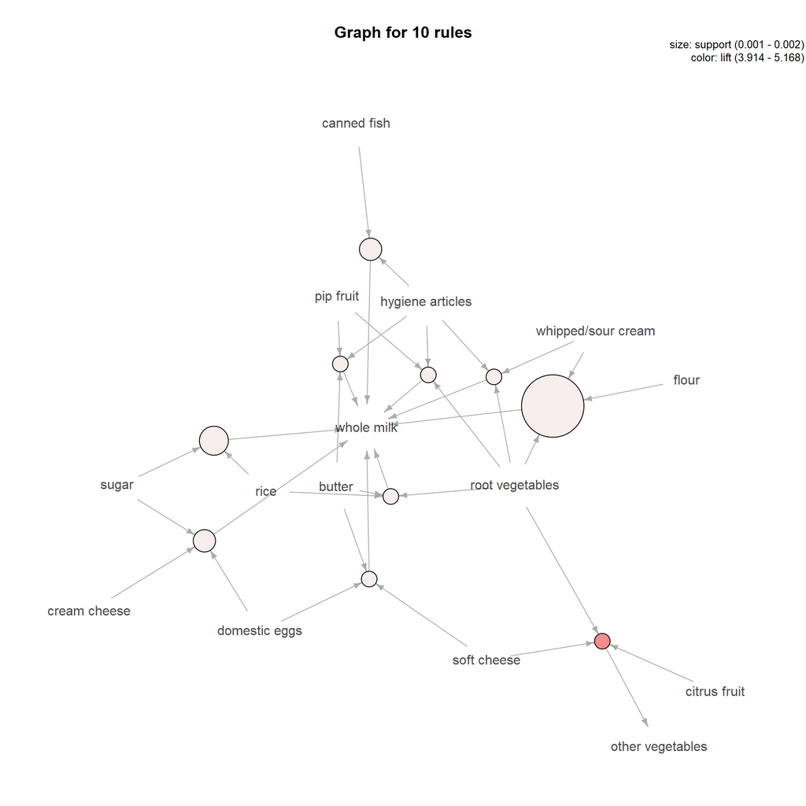

```r
# Get 10 rules with the highest confidence value
highconfidence <- head(sort(rules, by = "confidence"), 10)

# Visualize rule
plot(highconfidence, method = "graph")
```

### **Conclusion**

Market Basket Analysis using can be used by retailers to uncover associations between items.

### **Post Test**

1. Based on the results of the above analysis, what products should Dito Mart sell in bundles? Why?